# Processing ONT Duplex Samples

Jake Reed

# 1. Installation

This package depends on MEME and minimap2. MEME is a motif analysis tool which is used to determine the most common telomere motifs in a reference genome. Minimap2 is a read aligner which is used to align reads to the reference genome. Both of these tools are required for the package to run.

## Install MEME

Download the software from https://meme-suite.org/meme/doc/download.html Type the following commands:

```bash
tar -zxf meme-5.5.7.tar.gz
cd meme-5.5.7
./configure --prefix=$HOME/meme --enable-build-libxml2 --enable-build-libxslt
make
make test
make install

# Edit your shell configuration file to add $HOME/meme/bin and $HOME/meme/libexec/meme-5.5.7 to your shell's path. This can often be done by editing the file named .profile to add the following line:

export PATH=$HOME/meme/bin:$HOME/meme/libexec/meme-5.5.7:$PATH
```

## Install minimap2

```bash
git clone https://github.com/lh3/minimap2
cd minimap2 && make
```

## Data

```bash
# Download SRA toolkit
wget --output-document sratoolkit.tar.gz https://ftp-trace.ncbi.nlm.nih.gov/sra/sdk/current/sratoolkit.current-ubuntu64.tar.gz
tar -vxzf sratoolkit.tar.gz
export PATH=$PATH:$PWD/sratoolkit.3.0.0-mac64/bin

# Download fastq file
prefetch --progress --resume yes -X 500G SRR28295757
fastq-dump SRR28295757
```

# 2. Showcase

## Load Libraries and Samples

```r
# Load libraries
library(TECAT)
```

```r
library(ggplot2)
library(cowplot)

# Sample name
sample_name <- "HG002"

# Load the TECAT package data
extdata <- system.file("extdata", package = "TECAT")
if(extdata == "") {
  # Fallback for when package isn't installed (during development/build)
  if(file.exists("~/cran/tecat/inst/extdata")) {
    extdata <- "~/cran/tecat/inst/extdata"
  } else {
    stop("Cannot find package extdata directory")
  }
}

#sample_file <- file.path("/path/to/sra_fastq/")
reference_file <- file.path(extdata, "chr_ends.fa.gz")
data_dir <- tempdir()
results_dir <- file.path("~/tmp", sample_name, "results")
dir.create(results_dir, showWarnings = FALSE, recursive = TRUE)

# Set options
options(width = 300)
options(meme_bin = "~/meme/bin")

# Set number of threads
threads <- 2
```

## Process Fastq

```r
# Split large fastq file into files that will occupy
# 2GB of RAM in order to take advantage of all processors
# (20) with given RAM (62GB).
if (!file.exists(list.files(file.path(dirname(sample_file), "split"),
  full.names = TRUE
)[1])) {
  stats_fl <- auto_split(
    in_fastq = sample_file,
    prefix = sample_name,
    threads = threads,
    out_dir = file.path(data_dir, "split"),
    target_ram_size_gb = 2
  )

  # Save stats
  saveRDS(stats_fl, file.path(
    results_dir,
    "stats_fl.rds"
  ))
}
```

## Process Reference Fastq

```r
# ONT Settings
motif_analysis <- telomere_motif(
  reference_file = reference_file,
  reference_telo_length = 2000,
  telo_motif_length = 6,
  number_of_motifs = 10,
  number_of_repeats = 10,
  platform = "ONT",
  threads = threads
)

print(paste("Number of motifs found: ", length(motif_analysis$motifs)))
cat("\n")
print(paste(
  "Grep pattern for pattern matching and initial search: ",
  motif_analysis$grep_list
))

# Save results
saveRDS(motif_analysis, file.path(results_dir, "motif_analysis_results.rds"))

# Clean up
gc()
```

## Isolate telomere reads

```r
# Run pattern searh on all split fastq files
file_list <- list.files(file.path(data_dir, "split"),
  full.names = TRUE
)

# Create output directory
out <- file.path(data_dir, "telo")
dir.create(out, showWarnings = FALSE)

# Search telomeres
## Need to explain in documentation that threads should match number of files
## This function requires > 4 GB of memory per thread.
search_res <- telo_search(
  fastq_files = file_list,
  grep_list = motif_analysis$grep_list,
  threads = threads,
  out_dir = out,
  return_telomeres = FALSE,
  verbose = FALSE,
  progress = TRUE
)

# Print some basic telomere finding statistics
head(search_res$telomere_stats)

# Save telomere_stats
saveRDS(search_res, file.path(
  results_dir,
  "telomere_stats.rds"
))

# Clean up
rm(list = c("file_list", "out"))
gc()
```

## Cut telomere reads into sliding windows

## If you are running this vignette without the full data set, start here and run this opts_chunk

```r
telomere_stats <- readRDS(file.path(
  extdata,
  "telomere_stats.rds"
))

telo_file <- file.path(extdata, "combined_telo.fa.gz")
```

```r
# Run sliding window on all telomere files
windows <- sliding_window_parallel(
  telomere_file = telo_file,
  window_length = 200,
  step = 100,
  environment = "linux",
  threads = threads
)
# Save windows
saveRDS(windows, file.path(
  results_dir,
  "windows.rds"
))
# Satus
cat("\nFinished processing all telomere files to sliding windows.", "\n")
```

```
#>
#> Finished processing all telomere files to sliding windows.
```

## Calculate frequency of telomere motifs in sliding windows

```r
# Load in data
motif_analysis <- readRDS(file.path(
  extdata,
  "motif_analysis_results.rds"
))
motifs <- as.character(motif_analysis$motifs)

# Directories
win_file <- file.path(
  results_dir,
  "windows.rds"
)

# For loop over all telomere windows files
wins <- readRDS(win_file)
length(wins)
```

```
#> [1] 36
```

```r
dir.create(file.path(results_dir, "frequencies"),
  showWarnings = FALSE
)

out_dir <- file.path(
  results_dir,
  "frequencies"
)
# Test
freqs <- frequencies(
  windows = wins,
  motifs = motifs,
  environment = "linux",
  parallel = TRUE,
  threads = threads,
  save_files = TRUE,
  progress = TRUE,
  out_dir = out_dir,
  verbose = FALSE
)
# Save Frequencies
saveRDS(freqs, file.path(
  results_dir,
  "freqs.rds"
))
cat("\nNumber of telomeres found: ", length(freqs), "\n")
```

```
#>
#> Number of telomeres found:  36
```

```r
cat("\nExample telomere frequencies:\n")
```

```
#>
#> Example telomere frequencies:
```

```r
knitr::kable(head(freqs[[1]]))
```

| start | end | window_length | telomere_count | motif_frequency | hit_motif | NA | sequence_name |
| --- | --- | --- | --- | --- | --- | --- | --- |
| 1 | 200 | 200 | 27 | 100 | ACCCYNACCC | 1 | HG002001_telomere_2 |
| 101 | 300 | 200 | 26 | 100 | ACCCYNACCC | 101 | HG002001_telomere_2 |
| 201 | 400 | 200 | 24 | 100 | ACCCYNACCC | 201 | HG002001_telomere_2 |
| 301 | 500 | 200 | 15 | 75 | ACCCYNACCC | 301 | HG002001_telomere_2 |
| 401 | 600 | 200 | 12 | 60 | ACCCYNACCC | 401 | HG002001_telomere_2 |
| 501 | 700 | 200 | 16 | 80 | ACCCYNACCC | 501 | HG002001_telomere_2 |

```r
cat("\n...")
```

```
#>
#> ...
```

```r
knitr::kable(tail(freqs[[1]]))
```

|  | start | end | window_length | telomere_count | motif_frequency | hit_motif | NA | sequence_name |
| --- | --- | --- | --- | --- | --- | --- | --- | --- |
| 255 | 25401 | 25600 | 200 | 2 | 6.000000 | GGGATT | 25401 | HG002001_telomere_2 |
| 256 | 25501 | 25700 | 200 | 1 | 3.000000 | CCCTGG | 25501 | HG002001_telomere_2 |
| 257 | 25601 | 25800 | 200 | 0 | 0.000000 | None | 25601 | HG002001_telomere_2 |
| 258 | 25701 | 25900 | 200 | 1 | 3.000000 | CCCTGG | 25701 | HG002001_telomere_2 |
| 259 | 25801 | 25931 | 131 | 1 | 4.580153 | GGTCCC | 25801 | HG002001_telomere_2 |
| 260 | 25901 | 25931 | 31 | 1 | 19.354839 | GGTCCC | 25901 | HG002001_telomere_2 |

```r
# Clean up
rm(list = setdiff(ls(), c(
  "freqs",
  "paths",
  "sample_name",
  "results_dir",
  "extdata",
  "reference_file",
  "data_dir",
  "threads"
)))
gc()
```

```
#>           used  (Mb) gc trigger  (Mb) limit (Mb) max used  (Mb)
#> Ncells 3598023 192.2    5545618 296.2         NA  5545618 296.2
#> Vcells 6330260  48.3   14786712 112.9      49152 10145031  77.5
```

# Determine telomere length

This data frame is produced from a subset of the data, and the following runs the method on all start and end threshold combinations. This allows for the next step to determine the optimal thresholds to use for the rest of the data.

```r
# Load data
telomere_frequencies <- readRDS(file.path(
  results_dir,
  "freqs.rds"
))

# Threshold determination
thresh_df <- determine_threshold(
  telomere_list = telomere_frequencies,
  threads = threads,
  sample_ratio = 0.025
)
```

```
#>
#> Determining thresholds for full
#>
#>            data set based off of downsampled data,
#>
#>            and start threshold of 50.
#>
#> Determining thresholds for full
#>
#>             data set based off of downsampled data,
#>
#>             and start threshold of 50.
```

```r
# Save threshold data
saveRDS(thresh_df, file.path(
  results_dir,
  "threshold_data.rds"
))
```

## Reformat Threshold Data

This section reformats the threshold data in order to facilitate visualization of the data in the next step.

```r
# Start sensitivity
start_number_of_telos <- unlist(lapply(thresh_df$start, function(x) {
  length(which(!is.na(x$telomere_end)))
}))
sensitivity_df <- data.frame(
  start = seq(1, 100, 1),
  end = rep(5, 100),
  number_of_telos = start_number_of_telos
)

# Telomere length
# End telomere length
telomere_lengths_end <- lapply(thresh_df$end, function(x) {
  vals <- x$telomere_length[!is.na(x$telomere_end)]
  x <- mean(vals)
  if (x != 0 & length(vals) > 1) {
    std_dev <- stats::sd(vals)
  } else {
    std_dev <- 0
  }
  ret_frame <- data.frame(
    mean = x,
    std_dev = std_dev
  )
  return(ret_frame)
})
end_df <- do.call(rbind, telomere_lengths_end)
telomere_length_df <- cbind(
  start = rep(20, 100),
  end = seq(1, 100, 1),
  end_df
)

# Print data
print(paste0("\nStart sensitivity data:"))
```

```
#> [1] "\nStart sensitivity data:"
```

```r
knitr::kable(head(sensitivity_df))
```

| start | end | number_of_telos |
| --- | --- | --- |
| 1 | 5 | 0 |
| 2 | 5 | 0 |
| 3 | 5 | 0 |
| 4 | 5 | 1 |
| 5 | 5 | 1 |
| 6 | 5 | 1 |

```r
print(paste0("\n..."))
```

```
#> [1] "\n..."
```

```r
knitr::kable(tail(sensitivity_df))
```

|  | start | end | number_of_telos |
| --- | --- | --- | --- |
| 95 | 95 | 5 | 1 |
| 96 | 96 | 5 | 1 |
| 97 | 97 | 5 | 1 |
| 98 | 98 | 5 | 1 |
| 99 | 99 | 5 | 1 |
| 100 | 100 | 5 | 0 |

```r
print(paste0("\n"))
```

```
#> [1] "\n"
```

```r
print(paste0("\nTelomere length data:"))
```

```
#> [1] "\nTelomere length data:"
```

```r
knitr::kable(head(telomere_length_df))
```

| start | end | mean | std_dev |
| --- | --- | --- | --- |
| 20 | 1 | 4994 | 0 |
| 20 | 2 | 4694 | 0 |
| 20 | 3 | 4694 | 0 |
| 20 | 4 | 4594 | 0 |
| 20 | 5 | 4594 | 0 |
| 20 | 6 | 4594 | 0 |

```r
print(paste0("\n..."))
```

```
#> [1] "\n..."
```

```r
knitr::kable(tail(telomere_length_df))
```

|  | start | end | mean | std_dev |
| --- | --- | --- | --- | --- |
| 95 | 20 | 95 | 4264 | 0 |
| 96 | 20 | 96 | 4264 | 0 |
| 97 | 20 | 97 | 4264 | 0 |
| 98 | 20 | 98 | 4264 | 0 |
| 99 | 20 | 99 | 4264 | 0 |
| 100 | 20 | 100 | 4264 | 0 |

# Find optimal thresholds

The method determines telomere boundaries using two threshold values for telomere frequency motifs in 200 bp rolling windows. The start threshold sets the minimum motif frequency required in the first window to identify a telomeric region, affecting the method’s sensitivity. The end threshold defines the minimum motif frequency that determines where the telomeric region ends - when a window falls below this threshold, that position marks the telomere length for that read. An optimal start threshold balances sensitivity, while the end threshold ensures accurate telomere length determination. The method’s performance hinges on these thresholds, as they directly influence the identification and measurement of telomeric regions in the sequencing data.

```r
thresholds <- optimal_thresholds(threshold_dataframe = thresh_df)
thresholds
```

```
#> $sensitivity
#> [1] 4
#>
#> $telomere_length
#> [1] 26
```

## Visualize Threshold data

We visualize how different start and stop threshold combinations affect both the number of identified telomeres and their average length to evaluate the telomere length determination method.

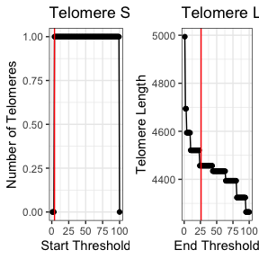

```r
# Plot sensitivity and telomere line graphs next to each other
sens_plot <- ggplot(sensitivity_df, aes(x = start, y = number_of_telos)) +
  geom_line() +
  geom_point() +
  geom_vline(xintercept = thresholds$sensitivity, color = "red") +
  labs(
    x = "Start Threshold",
    y = "Number of Telomeres",
    title = "Telomere Sensitivity"
  ) +
  theme_bw()

telomere_plot <- ggplot(telomere_length_df, aes(x = end, y = mean)) +
  geom_line() +
  geom_point() +
  geom_vline(xintercept = thresholds$telomere, color = "red") +
  labs(
    x = "End Threshold",
    y = "Telomere Length",
    title = "Telomere Length"
  ) +
  theme_bw()

plot_grid(sens_plot, telomere_plot, ncol = 2)
```

```r
# Print best thresholds
best_start <- sensitivity_df$start[which.max(sensitivity_df$number_of_telos)]
print(paste0("\nBest start threshold: ", best_start, "\n"))
```

```
#> [1] "\nBest start threshold: 4\n"
```

```r
best_end <- telomere_length_df$end[which.max(telomere_length_df$mean)]
print(paste0("\nBest end threshold: ", best_end, "\n"))
```

```
#> [1] "\nBest end threshold: 1\n"
```

## Determine optimal thresholds

We use the optimal thresholds found in the previous step and apply them to the entire dataset in order to determine telomere lengths.

```r
# Load data
telomere_frequencies <- readRDS(file.path(
  results_dir,
  "freqs.rds"
))

# Setup parallel environment
cl <- parallel::makeCluster(threads)
parallel::clusterExport(cl, c("findTelLength"),
  envir = environment()
)

# Load plyr inside the cluster only
invisible(parallel::clusterEvalQ(cl, {
  if (!requireNamespace("plyr", quietly = TRUE)) {
    stop("plyr package is needed for this vignette")
  }
  library(plyr)
  NULL
}))

results <- invisible(parallel::parLapply(cl, telomere_frequencies,
  findTelLength,
  st.thresh = thresholds$sensitivity,
  en.thresh = thresholds$telomere_length
))

# Stop the cluster
parallel::stopCluster(cl)

results_df <- do.call(rbind.data.frame, results)

head(results_df)
```

```
#>                      telomere_length read_length trunc_start trunc_end telomere_end
#> HG002001_telomere_2                0       25931           1     25931         <NA>
#> HG002001_telomere_4             6001       22304        6002     22304            L
#> HG002001_telomere_5             6911       40983        6912     40983            L
#> HG002001_telomere_12               0       36327           1     36327         <NA>
#> HG002001_telomere_14            6892       22352           1     15460            R
#> HG002001_telomere_21            4797       27217           1     22420            R
```

```r
# Save results
saveRDS(results_df, file.path(
  results_dir,
  "results_df.rds"
))

# Look at average length in telomeres
telomere_lengths <- results_df$telomere_length[which(!is.na(results_df$telomere_end) &
  results_df$telomere_length > 0)]

# Print fraction na
print(paste0("Fraction NA: ", sum(is.na(results_df$telomere_end)) / nrow(results_df)))
```

```
#> [1] "Fraction NA: 0.138888888888889"
```

```r
# Telomere update print(paste0)
print(paste0("Number of telomeres found: ", length(telomere_lengths), "\n"))
```

```
#> [1] "Number of telomeres found: 31\n"
```

```r
wo_na <- results_df[!is.na(results_df$telomere_end), ]
print(paste0("Mean telomere length at 20-15 without NA: ", mean(wo_na$telomere_length)))
```

[output not shown]

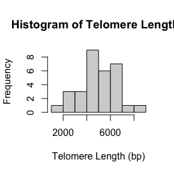

```r
# Add this check before creating the histogram
if(length(telomere_lengths) > 1) {
  # Calculate number of breaks, ensuring a minimum of 2
  num_breaks <- max(2, round(sqrt(length(telomere_lengths))))

  # Create histogram of telomere lengths
  hist(telomere_lengths,
    breaks = num_breaks,
    main = "Histogram of Telomere Lengths",
    xlab = "Telomere Length (bp)",
    ylab = "Frequency"
  )
} else {
  # Create an empty plot with a message when insufficient data
  plot(0, 0, type = "n", axes = FALSE, xlab = "", ylab = "")
  text(0, 0, "Insufficient telomere length data for histogram", cex = 1.5)
}
```

# Truncation and Mapping

After identifying the telomeric region, the method trims the read at this boundary and maps the remaining sequence to the reference genome.

```r
# Load data
results_df <- readRDS(file.path(
  results_dir,
  "results_df.rds"
))

# Remove NAs
results_df <- results_df[!is.na(results_df$telomere_end), ]
ls()
```

```
#>  [1] "best_end"              "best_start"            "cl"                    "data_dir"              "end_df"                "extdata"               "freqs"                 "num_breaks"            "reference_file"        "results"               "results_df"            "results_dir"
#> [13] "sample_name"           "sens_plot"             "sensitivity_df"        "start_number_of_telos" "telomere_frequencies"  "telomere_length_df"    "telomere_lengths"      "telomere_lengths_end"  "telomere_plot"         "threads"               "thresh_df"             "thresholds"
#> [25] "wo_na"
```

```r
find_sizes()
```

[output not shown]

```r
telomere_file <- file.path(extdata, "combined_telo.fa.gz")
#telomere_file <- file.path(data_dir, "telo", "combined_telo.fa.gz")
ref_file <- reference_file

# Truncate telomeres
trunc_dir <- file.path(data_dir, "trunc")
dir.create(trunc_dir, showWarnings = FALSE)

# Truncate files
fasta_fl <- truncate_file(
  combined_telomere_file = telomere_file,
  results_data_frame = results_df,
  out_dir = trunc_dir,
  write_file = TRUE,
  return = FALSE
)
```

```
#>
#> Writing files to: /var/folders/5v/ln0t2kjj24g0vmr9t6qwp2rh0000gp/T//RtmprRzVmp/trunc
```

```r
# Map reads to reference
combined_fasta <- file.path(trunc_dir, "truncated_reads.fa")
map_dir <- file.path(data_dir, "map")
dir.create(map_dir, showWarnings = FALSE)

# Map reads
mapped_output <- map(
  fasta = combined_fasta,
  results_data_frame = results_df,
  reference_file = ref_file,
  preset_string = "map-ont",
  out_dir = map_dir,
  return_mapped = TRUE,
  threads = threads
)
```

```
#> Generating output file: /var/folders/5v/ln0t2kjj24g0vmr9t6qwp2rh0000gp/T//RtmprRzVmp/map/mapped
#> Running minimap2...
#> Running minimap with the following command:
#> /Users/jakereed/mamba/bin/minimap2 -ax map-ont -t 2 /Users/jakereed/Library/R/arm64/4.4/library/TECAT/extdata/chr_ends.fa.gz /var/folders/5v/ln0t2kjj24g0vmr9t6qwp2rh0000gp/T//RtmprRzVmp/trunc/truncated_reads.fa -o /var/folders/5v/ln0t2kjj24g0vmr9t6qwp2rh0000gp/T//RtmprRzVmp/map/mapped.sam --secon…
```

```r
# Check if mapping was successful
mapped_output$results
```

```
#>               telo_name ref_name strand  start    end qwidth score telomere_length read_length trunc_start trunc_end telomere_end chromEnd
#> 1   HG002002_telomere_8     chr1      +   2816   7970   5155     1            5021       10176        5022     10176            L       5'
#> 2   HG002001_telomere_4     chr1      +   2880  19182  16303    30            6001       22304        6002     22304            L       5'
#> 3  HG002001_telomere_26     chr1      + 187810 196364   8555    55            8486       17041           1      8555            R       3'
#> 4   HG002002_telomere_3     chr2      - 174183 197504  23322     1            4107       27429        4108     27429            L       3'
#> 5   HG002005_telomere_8     chr3      - 177359 193432  16074    60            4501       20575        4502     20575            L       3'
#> 6  HG002005_telomere_25     chr5      + 174340 198329  23990    60            5256       29246           1     23990            R       3'
#> 7  HG002005_telomere_24     chr7      -   3441  30334  26894    60            3919       30813           1     26894            R       5'
#> 8   HG002003_telomere_4     chr7      - 151202 197601  46400    60            2507       48907        2508     48907            L       3'
#> 9  HG002004_telomere_11     chr8      - 169315 194633  25319    60            6111       31430        6112     31430            L       3'
#> 10  HG002004_telomere_5    chr10      +   2871  28301  25431    60            6921       32352        6922     32352            L       5'
#> 11 HG002003_telomere_23    chr10      -   2987  73023  70037    60            2912       72949           1     70037            R       5'
#> 12  HG002005_telomere_6    chr11      +   1955  16474  14520    60            6501       21021        6502     21021            L       5'
#> 13 HG002002_telomere_17    chr11      -   1999  38798  36800    60            5683       42483           1     36800            R       5'
#> 14  HG002005_telomere_5    chr11      +   2002  26129  24128    47            4551       28679        4552     28679            L       5'
```

[output cut: 19 more lines]

```r
# Save mapped output
saveRDS(mapped_output, file.path(
  results_dir,
  "mapped_output.rds"
))
```

# Plotting

```r
# Load data
mapped_output <- readRDS(file.path(
  results_dir,
  "mapped_output.rds"
))

mapped_output$results
```

```
#>               telo_name ref_name strand  start    end qwidth score telomere_length read_length trunc_start trunc_end telomere_end chromEnd
#> 1   HG002002_telomere_8     chr1      +   2816   7970   5155     1            5021       10176        5022     10176            L       5'
#> 2   HG002001_telomere_4     chr1      +   2880  19182  16303    30            6001       22304        6002     22304            L       5'
#> 3  HG002001_telomere_26     chr1      + 187810 196364   8555    55            8486       17041           1      8555            R       3'
#> 4   HG002002_telomere_3     chr2      - 174183 197504  23322     1            4107       27429        4108     27429            L       3'
#> 5   HG002005_telomere_8     chr3      - 177359 193432  16074    60            4501       20575        4502     20575            L       3'
#> 6  HG002005_telomere_25     chr5      + 174340 198329  23990    60            5256       29246           1     23990            R       3'
#> 7  HG002005_telomere_24     chr7      -   3441  30334  26894    60            3919       30813           1     26894            R       5'
#> 8   HG002003_telomere_4     chr7      - 151202 197601  46400    60            2507       48907        2508     48907            L       3'
#> 9  HG002004_telomere_11     chr8      - 169315 194633  25319    60            6111       31430        6112     31430            L       3'
#> 10  HG002004_telomere_5    chr10      +   2871  28301  25431    60            6921       32352        6922     32352            L       5'
#> 11 HG002003_telomere_23    chr10      -   2987  73023  70037    60            2912       72949           1     70037            R       5'
#> 12  HG002005_telomere_6    chr11      +   1955  16474  14520    60            6501       21021        6502     21021            L       5'
#> 13 HG002002_telomere_17    chr11      -   1999  38798  36800    60            5683       42483           1     36800            R       5'
#> 14  HG002005_telomere_5    chr11      +   2002  26129  24128    47            4551       28679        4552     28679            L       5'
```

[output cut: 19 more lines]

```
#> Registering fonts with R
#> Warning: Cannot compute density for groups with fewer than two datapoints.
#> Cannot compute density for groups with fewer than two datapoints.
#> $histogram
```

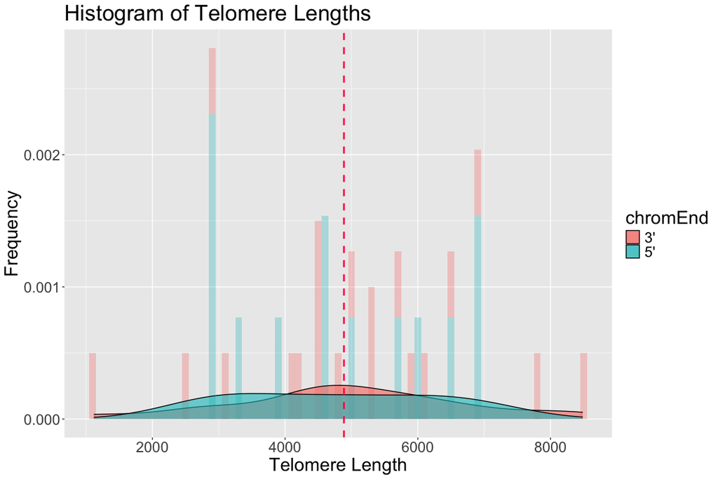

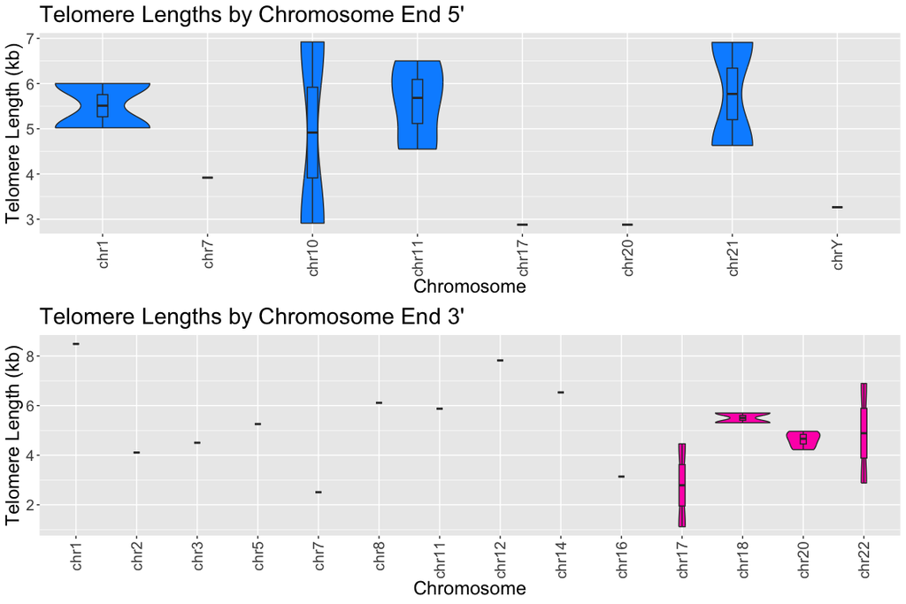

```r
# Add a check before trying to modify the data frame
if (nrow(mapped_output$results) > 0) {
  mapped_output$results$sample <- sample_name

  # Create violin plot of mapped_output with top and bottom panels
  library(extrafont)
  loadfonts()

  chromesome_plt <- tecat_plot(mapped_output = mapped_output,
    out_dir = results_dir,
    prefix = sample_name,
    save_plots = TRUE,
    return = TRUE)

  # Print the chromesome plot
  chromesome_plt
} else {
  # Create a placeholder message or simple plot when data is missing
  plot(0, 0, type = "n", axes = FALSE, xlab = "", ylab = "")
  text(0, 0, "No mapping results available for plotting", cex = 1.5)
}
```

# Exporting Results

Produce CSV table of results.

```r
data <- mapped_output$results

if (!is.null(data) && nrow(data) > 0) {
  head(data)
  new <- data.frame(data[, c(1:13)])
  rand_telo <- round(rnorm(nrow(new),
    mean = mean(data$telomere_length, na.rm = TRUE),
    sd = stats::sd(data$telomere_length, na.rm = TRUE)
  ))

  # Save csv file
  write.csv(data, file = file.path(
    results_dir,
    "output_results.csv"
  ))
} else {
  message("No data available to export.")
}
```

# Run RShiny

```r
# Run RShiny
launch_dashboard()
```